# Project: Investigate a Dataset - No-Show Appointments

By: Christina Jernberg

- Introduction
- Data Wrangling
- Exploratory Data Analysis
- Conclusions

## Introduction

### Dataset Description

> The dataset used in this analysis contains information on over 110,000 medical appointments in Brazil and focuses on whether patients attended their appointments. Each record includes demographic data (e.g., gender, age), information on several medical conditions (diabetes, hypertension, alcoholism), enrollment in the Brazilian welfare program (scholarship), whether the patient received an SMS reminder, and whether the patient no-showed. The dataset also includes a variable indicating whether the patient is handicapped, though no additional context about the nature of the handicaps is provided. The handicapped variable is categorized with numeric labels ranging from 0 to 4.

```python
#import Pandas & NumPy
import pandas as pd
import numpy as np
import matplotlib.pyplot as plt
import string
```

## Data Wrangling

### General Properties

> Our dataset contains 110,527 records of medical appointments and 14 variables associated with those appointments, of which 6 are Boolean(Scholarship, Hipertension, Diabetes, Alcoholism and SMS_received, and No-show), 6 Categorical columns (PatientId, AppointmentID, Gender, Age, Neighborhood and Handcap), 2 Datetime columns (ScheduledDay, Appointment Day) and 1 numeric column (Age, since we will be using it both categorically and numerically).

> The dataset has duplicates in the PatientId variable, but not the AppointmentId variable, which indicates that each row is a unique appointment. It is likely the AppointmentId is the index. There are no nulls in the dataset.

```python
#So that I can easily find the statistics and trend information during the visualization
#process, I've chosen to collect the bulk of them in one location to print out. This is
#the best method for my process.

#Reading dataset into memory
df_noshow = pd.read_csv('noshowappointments-kagglev2-may-2016.csv')


# Descriptive statistics

# shape
shape_dataset = df_noshow.shape

# Min and max ages
min_age = df_noshow['Age'].min()
max_age = df_noshow['Age'].max()

# counts of the values of the handcap column
handcap_counts = df_noshow['Handcap'].value_counts().sort_index()

# % of total population with handcap 1, 2, 3, 4. 108,000+ appointments contain 0, inferring
# that 0 is "not handicapped".
handcap_nonzero = (df_noshow['Handcap'] > 0).sum()

perc_handcap = handcap_nonzero / len(df_noshow) * 100

# Number of unique patients
num_patients = df_noshow['PatientId'].nunique()

# Count of total appointments booked by people with multiple appointments
count_apts_mult_bookings = df_noshow['PatientId'].duplicated().sum()

# Count of no-shows
count_noshow = df_noshow['No-show'].value_counts()

# Number of unique appointmentID's
num_appt_id = df_noshow['AppointmentID'].nunique()

# Number of unique neighborhoods
num_neighborhoods = df_noshow['Neighbourhood'].nunique()

# Distribution of gender
gender_counts = df_noshow['Gender'].value_counts()

# Summary statistics for age
age_summary = df_noshow['Age'].describe()

# Looking at unique values
uniques = df_noshow.nunique()

#Checking to see what data types we're working with
noshow = df_noshow.dtypes

# Looking to see if we have any missing data.
noshow_nulls = df_noshow.isna().sum()

# Compute overall no-show rate
overall_noshows = (df_noshow['No-show'] == "Yes").sum()
overall_shows = (df_noshow['No-show'] == "No").sum()
total_appts = overall_noshows + overall_shows
overall_noshow_rate = (overall_noshows / total_appts)*100

# Creating a dictionary for a nicer print

descriptive_stats = {
    'shape_dataset' : shape_dataset,
    'min_age' : min_age,
    'max_age' : max_age,
    'handcap_value_count': handcap_counts,
    'perc_handcap' : perc_handcap,
    'num_patients' : num_patients,
    'count_unq_patients': num_patients,
    'count_apts_mult_bookings' : count_apts_mult_bookings,
    'count_noshow' : count_noshow,
    'count_unq_neighborhoods' : num_neighborhoods,
    'count_unq_appointments' : num_appt_id,
    'gender_counts' : gender_counts,
    'age_summary' : age_summary,
    'overall_noshow_rate' : overall_noshow_rate,
    'uniques' : uniques,
    'df_noshow_dtypes' : noshow,
    'df_noshow_nulls' : noshow_nulls
}

for name, value in descriptive_stats.items():
    print(f"{name}:\n{value}\n")
```

```
shape_dataset:
(110527, 14)

min_age:
-1

max_age:
115

handcap_value_count:
0    108286
1      2042
2       183
3        13
4         3
Name: Handcap, dtype: int64

perc_handcap:
2.0275588770164754

num_patients:
62299

count_unq_patients:
62299

count_apts_mult_bookings:
48228

count_noshow:
No     88208
Yes    22319
Name: No-show, dtype: int64

count_unq_neighborhoods:
81

count_unq_appointments:
110527

```

[output cut: 54 more lines]

```
PatientId         0
AppointmentID     0
Gender            0
ScheduledDay      0
AppointmentDay    0
Age               0
Neighbourhood     0
Scholarship       0
Hipertension      0
Diabetes          0
Alcoholism        0
Handcap           0
SMS_received      0
No-show           0
dtype: int64
```

```python
num_patients = 62299
```

```python
# Looking to see the data format and column headers
df_noshow.head()
```

|  | PatientId | AppointmentID | Gender | ScheduledDay | AppointmentDay | Age | Neighbourhood | Scholarship | Hipertension | Diabetes | Alcoholism | Handcap | SMS_received | No-show |
| --- | --- | --- | --- | --- | --- | --- | --- | --- | --- | --- | --- | --- | --- | --- |
| 0 | 2.987250e+13 | 5642903 | F | 2016-04-29T18:38:08Z | 2016-04-29T00:00:00Z | 62 | JARDIM DA PENHA | 0 | 1 | 0 | 0 | 0 | 0 | No |
| 1 | 5.589978e+14 | 5642503 | M | 2016-04-29T16:08:27Z | 2016-04-29T00:00:00Z | 56 | JARDIM DA PENHA | 0 | 0 | 0 | 0 | 0 | 0 | No |
| 2 | 4.262962e+12 | 5642549 | F | 2016-04-29T16:19:04Z | 2016-04-29T00:00:00Z | 62 | MATA DA PRAIA | 0 | 0 | 0 | 0 | 0 | 0 | No |
| 3 | 8.679512e+11 | 5642828 | F | 2016-04-29T17:29:31Z | 2016-04-29T00:00:00Z | 8 | PONTAL DE CAMBURI | 0 | 0 | 0 | 0 | 0 | 0 | No |
| 4 | 8.841186e+12 | 5642494 | F | 2016-04-29T16:07:23Z | 2016-04-29T00:00:00Z | 56 | JARDIM DA PENHA | 0 | 1 | 1 | 0 | 0 | 0 | No |

```python
# The appointment dates are showing as an object data type, but appear to be in datetime
# format, so we'll look a little further at that.

df_noshow['ScheduledDay'].apply(type).value_counts()
```

```
<class 'str'>    110527
Name: ScheduledDay, dtype: int64
```

```python
# We'll verify that Scholarship, Hipertension, Diabetes, Alcoholism, and SMS_received
# are boolean by looking at what the unique values are. We will also see the possilbe
# results for Handcap.

df_noshow[['Scholarship', 'Hipertension', 'Diabetes',
           'Alcoholism', 'Handcap', 'SMS_received', 'No-show']].apply(pd.Series.unique)

## We see that Scholarship, Hipertension, Diabetes, Alcoholism and SMS_received only have
## 0 or 1 as contents. These should be boolean, which we will need to remember to do in
## the data cleaning step.
```

```
Scholarship              [0, 1]
Hipertension             [1, 0]
Diabetes                 [0, 1]
Alcoholism               [0, 1]
Handcap         [0, 1, 2, 3, 4]
SMS_received             [0, 1]
No-show               [No, Yes]
dtype: object
```

```python
#I would like to look at a list of frequencies for the ages in our dataset.

df_noshow['Age'].value_counts()

##Will need to look into why there might be a -1 in the age category, but it's only for 1
##patient, so it's unlikely to affect our data too much. We can see our list has 104 lines
##which means almost every age between 0 and 115 is represented. We can see the age 115 is
##listed 5 times. This is likely the same person, but we won't know until we remove
##duplicates. The spread of the age range, however, may be able to give us some information
##about who is likelyest to miss an appointment.
```

```
 0      3539
 1      2273
 52     1746
 49     1652
 53     1651
        ...
 115       5
 100       4
 102       2
 99        1
-1         1
Name: Age, Length: 104, dtype: int64
```

### Data Cleaning

1. (a)Some of the data types need to be corrected in order to work with them properly. The "ScheduledDay" and "AppointmentDay" column need to be in Datetime format to use mathematical calculations on them. (b)The "Scholarship", "Hipertension", "Alcoholism", "SMS_received" and "No-Show" are booleans in the nature of their data, but are listed as object data types. (c)Because the contents of "No-Show" contains "Yes" and "No" values rather than 0's and 1's, we will need to map these values, once we merge everything back into a single dataset.
2. The hyphen in the last column "No-show" will cause problems when trying to run dot notation. The hyphen will be changed to an underscore to maintain readability and use.
3. The capital letters in the headers also can be easy to inadvertantly miss, which again will cause issues with dot notation. The capital letters will be made lowercase to maintain readability and use. I will also strip leading and trailing spaces to ensure that our coding works properly.
4. The age range is really wide (-1 to 115). It's difficult to see trends with a range this wide. We will add age categories to help us better detect trends.

```python
# 1a. Converting ScheduledDay and AppointmentDay to datetime data type.
# To keep our original clean, we'll copy the data we're manipulating to a new data frame
# before manipulation. This helps to prevent corrosion and gives us a restore point.

df_apptDatetime = df_noshow[['ScheduledDay', 'AppointmentDay']].copy()

# Converting the datetime columns to datetime.

df_apptDatetime['ScheduledDay'] = pd.to_datetime(df_apptDatetime['ScheduledDay'])
df_apptDatetime['AppointmentDay'] = pd.to_datetime(df_apptDatetime['AppointmentDay'])

# checking to see that the datatype correctly changed

df_apptDatetime.dtypes
```

```
ScheduledDay      datetime64[ns, UTC]
AppointmentDay    datetime64[ns, UTC]
dtype: object
```

```python
# 1b. Converting Scholarship, Hipertension, Diabetes, Alcoholism, and SMS_received columns to
# boolean data type

df_bools = df_noshow[['Scholarship', 'Hipertension', 'Diabetes', 'Alcoholism',
                     'SMS_received']].copy()

# Converting these columns to boolean

df_bools['Scholarship'] = df_bools['Scholarship'].astype(bool)
df_bools['Hipertension'] = df_bools['Hipertension'].astype(bool)
df_bools['Diabetes'] = df_bools['Diabetes'].astype(bool)
df_bools['Alcoholism'] = df_bools['Alcoholism'].astype(bool)
df_bools['SMS_received'] = df_bools['SMS_received'].astype(bool)
# checking to see that the datatype correctly changed


df_bools.dtypes
df_bools.head()
```

|  | Scholarship | Hipertension | Diabetes | Alcoholism | SMS_received |
| --- | --- | --- | --- | --- | --- |
| 0 | False | True | False | False | False |
| 1 | False | False | False | False | False |
| 2 | False | False | False | False | False |
| 3 | False | False | False | False | False |
| 4 | False | True | True | False | False |

```python
# 1c. Merging all data sets back into 1 and then splitting them into appointments that
# no-showed and appointments that happened as planned.

df_merged = pd.concat([
    df_noshow[['PatientId', 'AppointmentID', 'Gender', 'Age', 'Neighbourhood', 'Handcap',
              'No-show']],
    df_apptDatetime[['ScheduledDay', 'AppointmentDay']],
    df_bools[['Scholarship', 'Hipertension', 'Diabetes', 'Alcoholism',
            'SMS_received']]
], axis=1)

# 1c. This ensures the system recognizes our boolean map for the df_merged data frame on the
# "no_show" column.

df_merged['No-show'] = df_merged['No-show'].map({'Yes': True, 'No': False})

df_merged.head()
```

|  | PatientId | AppointmentID | Gender | Age | Neighbourhood | Handcap | No-show | ScheduledDay | AppointmentDay | Scholarship | Hipertension | Diabetes | Alcoholism | SMS_received |
| --- | --- | --- | --- | --- | --- | --- | --- | --- | --- | --- | --- | --- | --- | --- |
| 0 | 2.987250e+13 | 5642903 | F | 62 | JARDIM DA PENHA | 0 | False | 2016-04-29 18:38:08+00:00 | 2016-04-29 00:00:00+00:00 | False | True | False | False | False |
| 1 | 5.589978e+14 | 5642503 | M | 56 | JARDIM DA PENHA | 0 | False | 2016-04-29 16:08:27+00:00 | 2016-04-29 00:00:00+00:00 | False | False | False | False | False |
| 2 | 4.262962e+12 | 5642549 | F | 62 | MATA DA PRAIA | 0 | False | 2016-04-29 16:19:04+00:00 | 2016-04-29 00:00:00+00:00 | False | False | False | False | False |
| 3 | 8.679512e+11 | 5642828 | F | 8 | PONTAL DE CAMBURI | 0 | False | 2016-04-29 17:29:31+00:00 | 2016-04-29 00:00:00+00:00 | False | False | False | False | False |
| 4 | 8.841186e+12 | 5642494 | F | 56 | JARDIM DA PENHA | 0 | False | 2016-04-29 16:07:23+00:00 | 2016-04-29 00:00:00+00:00 | False | True | True | False | False |

```python
# 2. Going to clean the headers up, remove a potential leading or trailing spaces and make
#the headers lower case.

df_merged.columns = df_merged.columns.str.strip().str.lower()

df_merged.head()
```

|  | patientid | appointmentid | gender | age | neighbourhood | handcap | no-show | scheduledday | appointmentday | scholarship | hipertension | diabetes | alcoholism | sms_received |
| --- | --- | --- | --- | --- | --- | --- | --- | --- | --- | --- | --- | --- | --- | --- |
| 0 | 2.987250e+13 | 5642903 | F | 62 | JARDIM DA PENHA | 0 | False | 2016-04-29 18:38:08+00:00 | 2016-04-29 00:00:00+00:00 | False | True | False | False | False |
| 1 | 5.589978e+14 | 5642503 | M | 56 | JARDIM DA PENHA | 0 | False | 2016-04-29 16:08:27+00:00 | 2016-04-29 00:00:00+00:00 | False | False | False | False | False |
| 2 | 4.262962e+12 | 5642549 | F | 62 | MATA DA PRAIA | 0 | False | 2016-04-29 16:19:04+00:00 | 2016-04-29 00:00:00+00:00 | False | False | False | False | False |
| 3 | 8.679512e+11 | 5642828 | F | 8 | PONTAL DE CAMBURI | 0 | False | 2016-04-29 17:29:31+00:00 | 2016-04-29 00:00:00+00:00 | False | False | False | False | False |
| 4 | 8.841186e+12 | 5642494 | F | 56 | JARDIM DA PENHA | 0 | False | 2016-04-29 16:07:23+00:00 | 2016-04-29 00:00:00+00:00 | False | True | True | False | False |

```python
# 3. fixing hyphen in "no-show" variable header.

df_merged.rename(columns={'no-show': 'no_show'}, inplace=True)

#verifying the fix
df_merged.head(1)
```

|  | patientid | appointmentid | gender | age | neighbourhood | handcap | no_show | scheduledday | appointmentday | scholarship | hipertension | diabetes | alcoholism | sms_received |
| --- | --- | --- | --- | --- | --- | --- | --- | --- | --- | --- | --- | --- | --- | --- |
| 0 | 2.987250e+13 | 5642903 | F | 62 | JARDIM DA PENHA | 0 | False | 2016-04-29 18:38:08+00:00 | 2016-04-29 00:00:00+00:00 | False | True | False | False | False |

```python
# 4. We saw before a pretty wide age range, so let's add some categories.

age_bins = [0, 14, 24, 44, 64, 120]  # define the numeric edges
age_labels = ['0‑14','15‑24','25‑44','45‑64','65+']  # one fewer label than bins

df_merged['age_group'] = pd.cut(df_merged['age'],
                                bins=age_bins,
                                labels=age_labels,
                                include_lowest=True)
#verifying fix
df_merged.head(15)
```

|  | patientid | appointmentid | gender | age | neighbourhood | handcap | no_show | scheduledday | appointmentday | scholarship | hipertension | diabetes | alcoholism | sms_received | age_group |
| --- | --- | --- | --- | --- | --- | --- | --- | --- | --- | --- | --- | --- | --- | --- | --- |
| 0 | 2.987250e+13 | 5642903 | F | 62 | JARDIM DA PENHA | 0 | False | 2016-04-29 18:38:08+00:00 | 2016-04-29 00:00:00+00:00 | False | True | False | False | False | 45‑64 |
| 1 | 5.589978e+14 | 5642503 | M | 56 | JARDIM DA PENHA | 0 | False | 2016-04-29 16:08:27+00:00 | 2016-04-29 00:00:00+00:00 | False | False | False | False | False | 45‑64 |
| 2 | 4.262962e+12 | 5642549 | F | 62 | MATA DA PRAIA | 0 | False | 2016-04-29 16:19:04+00:00 | 2016-04-29 00:00:00+00:00 | False | False | False | False | False | 45‑64 |
| 3 | 8.679512e+11 | 5642828 | F | 8 | PONTAL DE CAMBURI | 0 | False | 2016-04-29 17:29:31+00:00 | 2016-04-29 00:00:00+00:00 | False | False | False | False | False | 0‑14 |
| 4 | 8.841186e+12 | 5642494 | F | 56 | JARDIM DA PENHA | 0 | False | 2016-04-29 16:07:23+00:00 | 2016-04-29 00:00:00+00:00 | False | True | True | False | False | 45‑64 |
| 5 | 9.598513e+13 | 5626772 | F | 76 | REPÚBLICA | 0 | False | 2016-04-27 08:36:51+00:00 | 2016-04-29 00:00:00+00:00 | False | True | False | False | False | 65+ |
| 6 | 7.336882e+14 | 5630279 | F | 23 | GOIABEIRAS | 0 | True | 2016-04-27 15:05:12+00:00 | 2016-04-29 00:00:00+00:00 | False | False | False | False | False | 15‑24 |
| 7 | 3.449833e+12 | 5630575 | F | 39 | GOIABEIRAS | 0 | True | 2016-04-27 15:39:58+00:00 | 2016-04-29 00:00:00+00:00 | False | False | False | False | False | 25‑44 |
| 8 | 5.639473e+13 | 5638447 | F | 21 | ANDORINHAS | 0 | False | 2016-04-29 08:02:16+00:00 | 2016-04-29 00:00:00+00:00 | False | False | False | False | False | 15‑24 |
| 9 | 7.812456e+13 | 5629123 | F | 19 | CONQUISTA | 0 | False | 2016-04-27 12:48:25+00:00 | 2016-04-29 00:00:00+00:00 | False | False | False | False | False | 15‑24 |
| 10 | 7.345362e+14 | 5630213 | F | 30 | NOVA PALESTINA | 0 | False | 2016-04-27 14:58:11+00:00 | 2016-04-29 00:00:00+00:00 | False | False | False | False | False | 25‑44 |
| 11 | 7.542951e+12 | 5620163 | M | 29 | NOVA PALESTINA | 0 | True | 2016-04-26 08:44:12+00:00 | 2016-04-29 00:00:00+00:00 | False | False | False | False | True | 25‑44 |
| 12 | 5.666548e+14 | 5634718 | F | 22 | NOVA PALESTINA | 0 | False | 2016-04-28 11:33:51+00:00 | 2016-04-29 00:00:00+00:00 | True | False | False | False | False | 15‑24 |
| 13 | 9.113946e+14 | 5636249 | M | 28 | NOVA PALESTINA | 0 | False | 2016-04-28 14:52:07+00:00 | 2016-04-29 00:00:00+00:00 | False | False | False | False | False | 25‑44 |
| 14 | 9.988472e+13 | 5633951 | F | 54 | NOVA PALESTINA | 0 | False | 2016-04-28 10:06:24+00:00 | 2016-04-29 00:00:00+00:00 | False | False | False | False | False | 45‑64 |

```python
# 5. Convert Handcap column to int type so we can plot.

df_merged['handcap'] = pd.to_numeric(df_merged['handcap'], errors='raise')

df_merged.dtypes
```

```
patientid                     float64
appointmentid                   int64
gender                         object
age                             int64
neighbourhood                  object
handcap                         int64
no_show                          bool
scheduledday      datetime64[ns, UTC]
appointmentday    datetime64[ns, UTC]
scholarship                      bool
hipertension                     bool
diabetes                         bool
alcoholism                       bool
sms_received                     bool
age_group                    category
dtype: object
```

```python
# Count appointments per patient
appointment_counts = df_merged.groupby('patientid')['appointmentid'].count()

# Get patient IDs with more than 1 appointment
multi_appointment_ids = appointment_counts[appointment_counts > 1].index

# Filter the original dataframe for only these patients
df_mult_appointments = df_merged[df_merged['patientid'].isin(multi_appointment_ids)].copy()

#verify df
df_mult_appointments.head()
```

|  | patientid | appointmentid | gender | age | neighbourhood | handcap | no_show | scheduledday | appointmentday | scholarship | hipertension | diabetes | alcoholism | sms_received | age_group |
| --- | --- | --- | --- | --- | --- | --- | --- | --- | --- | --- | --- | --- | --- | --- | --- |
| 0 | 2.987250e+13 | 5642903 | F | 62 | JARDIM DA PENHA | 0 | False | 2016-04-29 18:38:08+00:00 | 2016-04-29 00:00:00+00:00 | False | True | False | False | False | 45‑64 |
| 1 | 5.589978e+14 | 5642503 | M | 56 | JARDIM DA PENHA | 0 | False | 2016-04-29 16:08:27+00:00 | 2016-04-29 00:00:00+00:00 | False | False | False | False | False | 45‑64 |
| 2 | 4.262962e+12 | 5642549 | F | 62 | MATA DA PRAIA | 0 | False | 2016-04-29 16:19:04+00:00 | 2016-04-29 00:00:00+00:00 | False | False | False | False | False | 45‑64 |
| 3 | 8.679512e+11 | 5642828 | F | 8 | PONTAL DE CAMBURI | 0 | False | 2016-04-29 17:29:31+00:00 | 2016-04-29 00:00:00+00:00 | False | False | False | False | False | 0‑14 |
| 5 | 9.598513e+13 | 5626772 | F | 76 | REPÚBLICA | 0 | False | 2016-04-27 08:36:51+00:00 | 2016-04-29 00:00:00+00:00 | False | True | False | False | False | 65+ |

```python
df_grouped_count_mult_bookings = df_mult_appointments.groupby('patientid')['appointmentid'].count()

df_grouped_count_mult_bookings.head()
```

```
patientid
22638656.0    2
52168938.0    2
64851211.0    2
79228495.0    2
87996454.0    2
Name: appointmentid, dtype: int64
```

```python
# Count number of appointments per patient
appointment_counts = df_merged.groupby('patientid')['appointmentid'].count()

# Filter patients with 2 or more appointments
multi_appointment_patients = appointment_counts[appointment_counts >= 2]

# Number of patients with 2 or more appointments
num_multi_appointment_patients = multi_appointment_patients.shape[0]

num_multi_appointment_patients
```

```
24379
```

```python
# Percentage of overall appointments held by people with >1 appointment
multi_mask = df_merged['patientid'].duplicated(keep=False)

total_multi_appts = multi_mask.sum()

perc_apts_by_mult_bookers = total_multi_appts / len(df_merged)
```

## Exploratory Data Analysis

### What affects do the gender, age, neighbourhood, scholarship, medical conditions, handicap and SMS_received have on no-show rates?

> 1. Next we'll apply the gender characteristic to the population to get the no-show rate by gender.
> 2. Next we'll plot the age and gender no-show rates. This visual should help spot any trends.
> 3. (a) Generally, there's not enough context with the neighbourhood characteristic, but we may be able to learn some information by plotting it against the gender distribution for no-shows. (b) We'll look at the top 15 neighborhoods by gender and appointment count.
> 4. We'll look at the Handcap data field by gender.
> 5. A quick table to look at the no-show rates by age grouping.
> 6. (a) We're going to plot no-show by age across another data field, but we're going to repeat this process, so there's a function here. (b) We're going to plot no-show rate by age group across another data field, but we're going to repeat this process, so there's another function.
> 7. (a & b) Two visuals plotting no-show rate by age group and gender across hypertension.
> 8. (a & b) Two visuals plotting no-show rate by age group and gender across diabetes.
> 9. (a & b) Two visuals plotting no-show rate by age group and gender across alcoholism.
> 10. (a & b) Two visuals plotting no-show rate by age group and gender across scholarship.
> 11. (a & b) Two visuals plotting no-show rate by age group and gender across sms_received.

```python
# 1. Get the no-show rate by gender.

gendered_no_show_rate = df_merged.groupby('gender')['no_show'].mean()

gendered_no_show_rate
```

```
gender
F    0.203146
M    0.199679
Name: no_show, dtype: float64
```

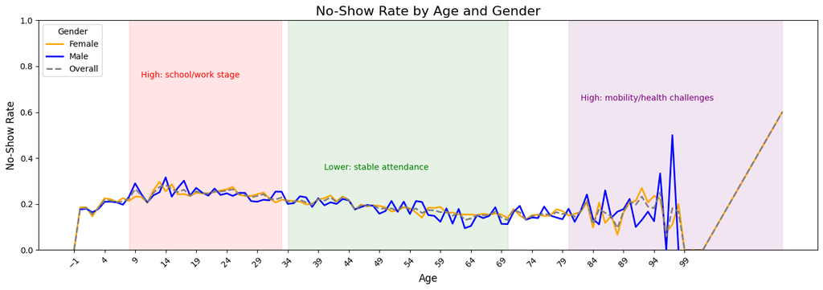

```python
# 2. Plotting no-show rate by age and gender.

# Compute no-show rate per age and gender
age_gender_no_show = df_merged.groupby(['age','gender'])['no_show'].mean().unstack()

# Set up the figure
plt.figure(figsize=(14,5))

# Plot each gender
plt.plot(age_gender_no_show.index, age_gender_no_show['F'], label='Female', color='orange', linewidth=2)
plt.plot(age_gender_no_show.index, age_gender_no_show['M'], label='Male', color='blue', linewidth=2)

# Compute overall no-show rate by age
overall_age_ns = df_merged.groupby('age')['no_show'].mean()

# Plot the overall line on top of the gender lines
plt.plot(overall_age_ns.index, overall_age_ns.values,
         label='Overall', color='gray', linestyle='--', linewidth=2)

# Title and labels
plt.title('No-Show Rate by Age and Gender', fontsize=16)
plt.xlabel('Age', fontsize=12)
plt.ylabel('No-Show Rate', fontsize=12)
plt.ylim(0,1)

# Limit x-axis ticks for readability (every 5 years)
plt.xticks(age_gender_no_show.index[::5], rotation=45)

# Highlight key age ranges with annotations
plt.axvspan(8, 33, color='red', alpha=0.1)  # high no-show for school/early career
plt.text(10, 0.75, 'High: school/work stage', color='red', fontsize=10)

plt.axvspan(34, 70, color='green', alpha=0.1)  # lower no-show middle-aged
plt.text(40, 0.35, 'Lower: stable attendance', color='green', fontsize=10)

plt.axvspan(80, 115, color='purple', alpha=0.1)  # high no-show elderly
plt.text(82, 0.65, 'High: mobility/health challenges', color='purple', fontsize=10)

# Add legend
plt.legend(title='Gender')

# Show plot
plt.tight_layout()
plt.show()
```

**Figure 1:** Line chart showing no-show rate by age and gender.

> Overall, the no-show is at its highest rates between the ages of 9 and 30, then gradually declines and stabilizes until around age 64. After age 80, the no-show rates begin to rise again.

> The rate is generally similar between males and females, with a few notable differences: females have slightly higher no-show rates between the ages of 24-30, 54-70, 89-95.

> These patterns align with life stages. Younger patients are often in school, and rely on others for transporation. As people transition to work, they must juggle work, appointments and other commitments, which may increase missed appointments. During middle age, routines stabilize, and no-show rates are lower. At retirement age, the rate drops further due to fewer work conflicts. This is likely due to people no longer having work commitments and still being in relatively good health. Finally, in very old age, mobility and health challenges likely contribute to higher no-show rates.

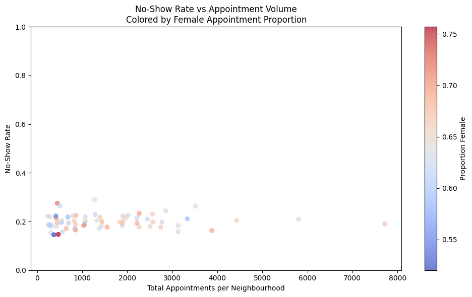

```python
# 3(a). Let's see how neighborhood and gender affects the no-show rates.

# Group by neighbourhood
neigh_summary = (
    df_merged
    .groupby('neighbourhood')
    .agg(
        total_appts=('no_show', 'count'),
        no_show_rate=('no_show', 'mean'),
        female_count=('gender', lambda x: (x == 'F').sum()),
        male_count=('gender', lambda x: (x == 'M').sum())
    )
    .reset_index()
)

# Calculate female proportion
neigh_summary['female_ratio'] = (
    neigh_summary['female_count'] / neigh_summary['total_appts']
)

# Optional: remove very small neighborhoods to reduce noise
neigh_summary = neigh_summary[neigh_summary['total_appts'] > 200]

# Create scatter plot
plt.figure(figsize=(10,6))

scatter = plt.scatter(
    neigh_summary['total_appts'],
    neigh_summary['no_show_rate'],
    c=neigh_summary['female_ratio'],   # color by % female
    cmap='coolwarm',
    alpha=0.7
)

plt.xlabel('Total Appointments per Neighbourhood')
plt.ylabel('No-Show Rate')
plt.title('No-Show Rate vs Appointment Volume\nColored by Female Appointment Proportion')
plt.ylim(0,1)

# Add colorbar
cbar = plt.colorbar(scatter)
cbar.set_label('Proportion Female')

plt.tight_layout()
plt.show()
```

**Figure 2:** Scatter plot showing no-show rate vs appointment volume by female proportion.

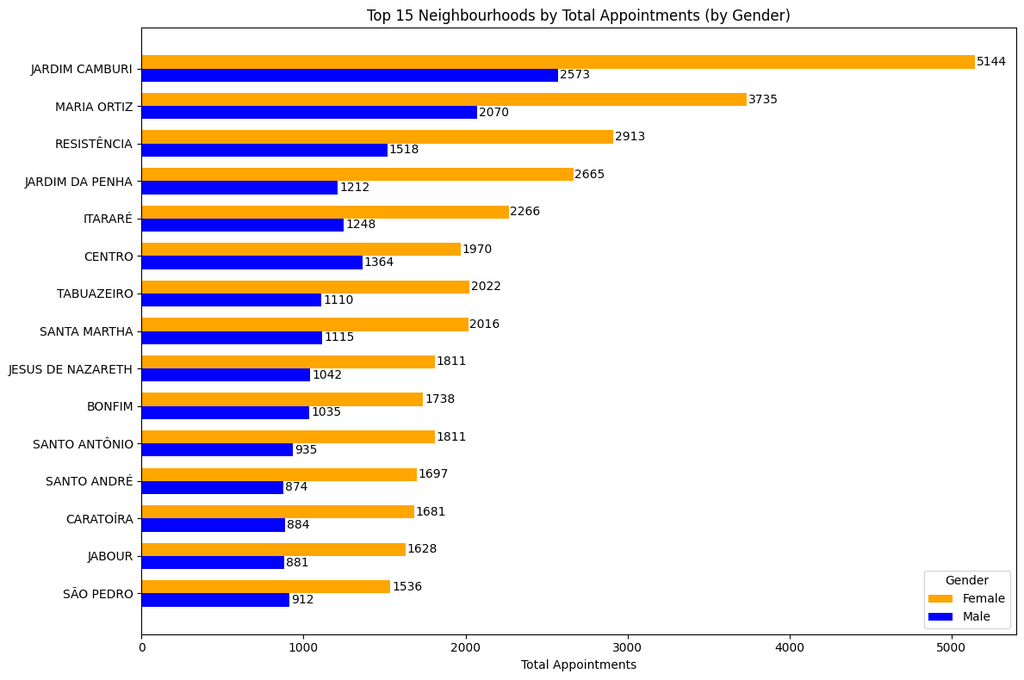

```python
# 3(b). Count appointments per neighbourhood and gender
neigh_gender_counts = (
    df_merged
    .groupby(['neighbourhood', 'gender'])['appointmentid']
    .count()
    .unstack(fill_value=0)  # makes separate columns for 'F' and 'M'
)

# Keep top 15 neighbourhoods by total appointments (all genders)
top_neigh = neigh_gender_counts.sum(axis=1).sort_values(ascending=False).head(15)

# Subset the dataframe to top neighbourhoods
neigh_gender_top = neigh_gender_counts.loc[top_neigh.index]

# Plot
plt.figure(figsize=(12,8))
x = np.arange(len(neigh_gender_top))  # positions on y-axis
width = 0.35

plt.barh(x - width/2, neigh_gender_top['F'], width, label='Female', color='orange')
plt.barh(x + width/2, neigh_gender_top['M'], width, label='Male', color='blue')

plt.xlabel('Total Appointments')
plt.title('Top 15 Neighbourhoods by Total Appointments (by Gender)')
plt.yticks(x, neigh_gender_top.index)
plt.gca().invert_yaxis()  # largest at top

# Add labels
for i in range(len(x)):
    plt.text(neigh_gender_top['F'].iloc[i]+10, x[i]-width/2, f"{neigh_gender_top['F'].iloc[i]}", va='center')
    plt.text(neigh_gender_top['M'].iloc[i]+10, x[i]+width/2, f"{neigh_gender_top['M'].iloc[i]}", va='center')

plt.legend(title='Gender')
plt.tight_layout()
plt.show()
```

**Figure 3:** Bar graph showing the top 15 neighborhoods by total appointments across gender.

> We don't have any geographic data beyond the neighborhood labels, so we can't infer much about location characteristics. Some areas have very few scheduled appointments, which likely reflects lower population density, but beyond that, patterns are unclear. In general, neighborhoods with higher numbers of scheduled appointments tend to have more stable no-show rates, although some volatility remains. Additional geographic information could help explain these differences, but without it, interpretation is limited.Overall, without more contextual data, the neighborhood characteristic alone does not provide much actionable insight.

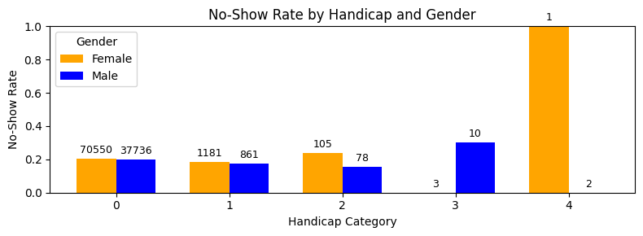

```python
# 4. Let's take a look at the handcap characteristic. We don't know what these category codes
# mean, but we can see the rates.

# Group by handicap and gender, compute mean no-show
handcap_gender_ns = df_merged.groupby(['handcap', 'gender'])['no_show'].mean().unstack()

# Also get counts to annotate
handcap_gender_counts = df_merged.groupby(['handcap', 'gender'])['no_show'].count().unstack()

# Set up figure
plt.figure(figsize=(8,3))

# X positions for the bars
x = np.arange(len(handcap_gender_ns.index))  # 0,1,2,3,4
width = 0.35  # width of bars

# Plot bars for each gender
plt.bar(x - width/2, handcap_gender_ns['F'], width, label='Female', color='orange')
plt.bar(x + width/2, handcap_gender_ns['M'], width, label='Male', color='blue')

# Labels and title
plt.title('No-Show Rate by Handicap and Gender')
plt.xlabel('Handicap Category')
plt.ylabel('No-Show Rate')
plt.ylim(0,1)
plt.xticks(x, handcap_gender_ns.index)  # show handicap numbers on x-axis

# Optional: annotate counts
for i in range(len(x)):
    plt.text(x[i] - width/2, handcap_gender_ns['F'].iloc[i]+0.02, str(handcap_gender_counts['F'].iloc[i]),
             ha='center', va='bottom', fontsize=9)
    plt.text(x[i] + width/2, handcap_gender_ns['M'].iloc[i]+0.02, str(handcap_gender_counts['M'].iloc[i]),
             ha='center', va='bottom', fontsize=9)

plt.legend(title='Gender')
plt.tight_layout()
plt.show()
```

**Figure 4:** Bar graph showing no-show rate by handicap and gender.

> Most appointments are booked by patients in the '0' handcap category, with females making up a larger share than males. Smaller handcap categories (1-4) have far fewer appointments, with females also generally booking more appointments than males. Categories 3 and 4 have very few appointments (combined total of 16), which makes graphical representation difficult.

```python
# 5. No-show rate by age group
age_no_show_table = (
    df_merged
    .groupby('age_group')['no_show']
    .agg(no_show_rate='mean', total_appointments='count')
    .reset_index()
)

age_no_show_table
```

|  | age_group | no_show_rate | total_appointments |
| --- | --- | --- | --- |
| 0 | 0‑14 | 0.211807 | 23257 |
| 1 | 15‑24 | 0.252677 | 14010 |
| 2 | 25‑44 | 0.223835 | 28865 |
| 3 | 45‑64 | 0.172013 | 29992 |
| 4 | 65+ | 0.155048 | 14402 |

```python
# 6(a). We'll make a function to help us plot no-show rate by age group and another given
# condition.

def plot_condition_vs_overall(df, condition_col, condition_label):
    """
    Plots no-show rate by age_group for a given condition,
    compared to overall population trend.
    """

    # Ensure numeric
    df[condition_col] = df[condition_col].astype(int)

    # Subgroup: condition == 1
    condition_ns = (
        df[df[condition_col] == 1]
        .groupby('age_group')['no_show']
        .mean()
        .reset_index()
    )

    # Overall population
    overall_ns = (
        df.groupby('age_group')['no_show']
        .mean()
        .reset_index()
    )

    plt.figure(figsize=(8,5))

    # Bars
    plt.bar(
        condition_ns['age_group'],
        condition_ns['no_show'],
        color='mediumseagreen',
        label=condition_label
    )

    # Line
    plt.plot(
        overall_ns['age_group'],
        overall_ns['no_show'],
        color='black',
        marker='o',
        linewidth=2,
        label='Overall Population'
    )

    # Annotate
    for i, val in enumerate(condition_ns['no_show']):
        plt.text(i, val + 0.01, f"{val:.2%}", ha='center')

    plt.xlabel('Age Group')
    plt.ylabel('No-Show Rate')
    plt.title(f'{condition_label} No-Show Rate by Age Group')
    plt.ylim(0,1)
    plt.legend()
    plt.tight_layout()
    plt.show()
```

```python
# 6(b). Another function to help us plot the boolean categories

def plot_age_gender_condition(df, condition_col, condition_label):
    """
    Plots no-show rate by age_group, gender, and a binary condition.
    Annotates bars with appointment counts.
    """

    # Ensure condition is int
    df[condition_col] = df[condition_col].astype(int)

    # Compute no-show rates
    age_cond_gender_ns = (
        df.groupby(['age_group', condition_col, 'gender'])['no_show']
        .mean()
        .unstack(level='gender')
    )

    # Compute counts
    age_cond_gender_counts = (
        df.groupby(['age_group', condition_col, 'appointmentid'])
        .count()
    )

    age_cond_gender_counts = (
        df.groupby(['age_group', condition_col, 'gender'])['appointmentid']
        .count()
        .unstack(level='gender')
    )

    age_groups = age_cond_gender_ns.index.get_level_values('age_group').unique()
    condition_status = [0, 1]
    width = 0.2

    plt.figure(figsize=(14,6))

    x_positions = []
    xtick_labels = []

    for i, age in enumerate(age_groups):
        for j, cond in enumerate(condition_status):
            x = i*len(condition_status)*width*2 + j*width*2
            x_positions.append(x)
            xtick_labels.append(f"{age} | {bool(cond)}")

            rate_F = age_cond_gender_ns.loc[(age, cond), 'F']
            rate_M = age_cond_gender_ns.loc[(age, cond), 'M']
            count_F = age_cond_gender_counts.loc[(age, cond), 'F']
            count_M = age_cond_gender_counts.loc[(age, cond), 'M']

            plt.bar(x - width/2, rate_F, width, color='orange',
                    label='F' if i==0 and j==0 else "")
            plt.bar(x + width/2, rate_M, width, color='blue',
                    label='M' if i==0 and j==0 else "")

            plt.text(x - width/2, rate_F + 0.02, str(count_F),
                     ha='center', va='bottom', fontsize=9)
            plt.text(x + width/2, rate_M + 0.02, str(count_M),
                     ha='center', va='bottom', fontsize=9)

    plt.xlabel(f'Age Group | {condition_label}')
    plt.ylabel('No-Show Rate')
    plt.title(f'No-Show Rate by Age Group, Gender, and {condition_label}')
    plt.xticks(x_positions, xtick_labels, rotation=45, ha='right')
    plt.ylim(0, 1.1)
    plt.legend()
    plt.tight_layout()
    plt.show()
```

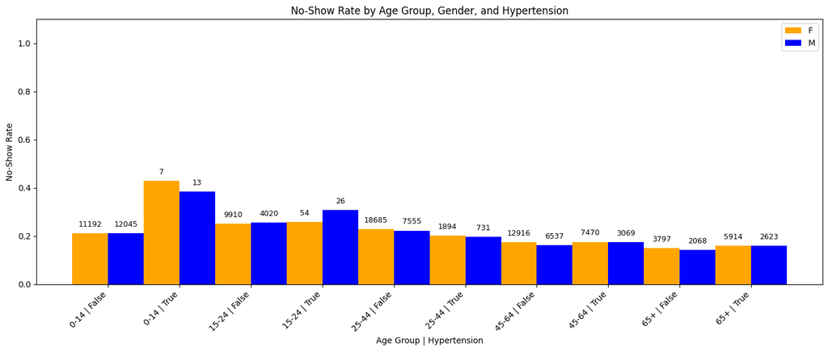

```python
# 7(a).

plot_age_gender_condition(df_merged, 'hipertension', 'Hypertension')
```

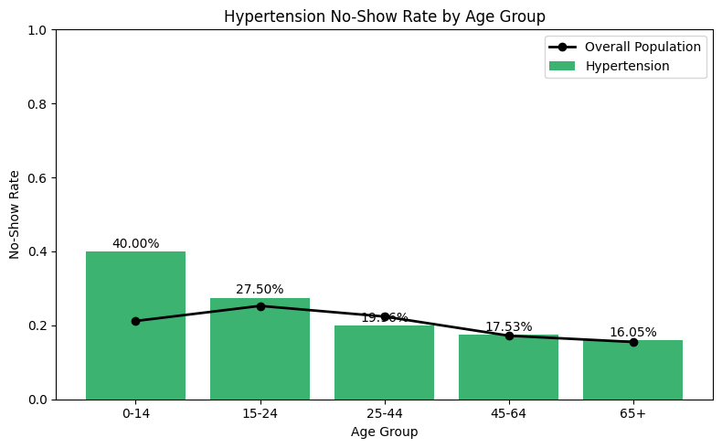

```python
# 7(b).

plot_condition_vs_overall(df_merged, 'hipertension', 'Hypertension')
```

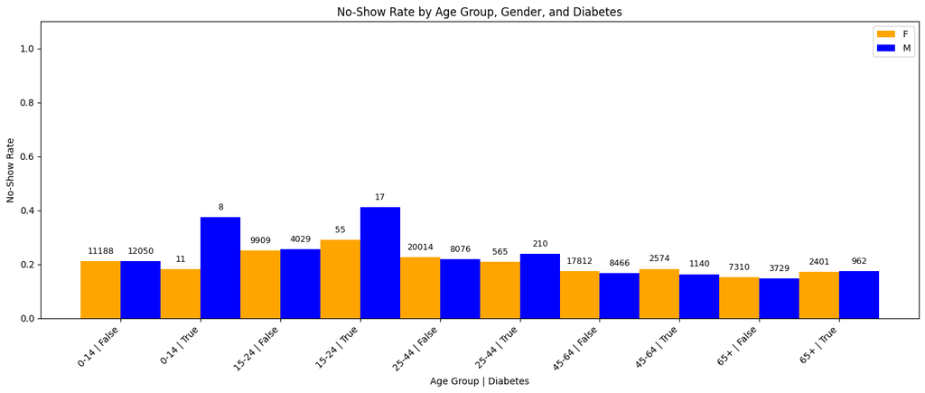

```python
# 8 (a).

plot_age_gender_condition(df_merged, 'diabetes', 'Diabetes')
```

**Figure 7:** Bar graph showing no-show rate by age, gender and diabetes.

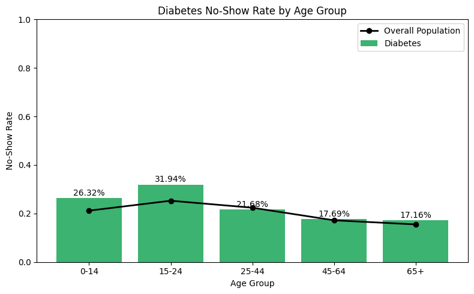

```python
# 8(b).

plot_condition_vs_overall(df_merged, 'diabetes', 'Diabetes')
```

> These charts show that diabetes is relatively uncommon in the younger age groups and begins to increase in occurence starting in the 25-44 age category. Among patients under 25, those with diabetes appeart to have slightly higher no-show rates than their peers without diabetes. However, there are fewer than 100 appointments associated with diabetes in patients below age 25, so these differences should be interpreted cautiously. Patients in the 15-24 age group appear to have a slightly higher no-show rate compared to the overall population trend. Above age 25, the no-show rate for patients with diabetes appears similar to that of the total population.

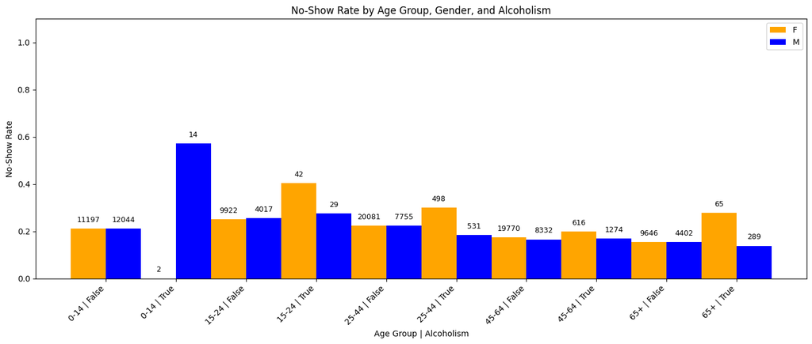

```python
# 9(a).

plot_age_gender_condition(df_merged, 'alcoholism', 'Alcoholism')
```

**Figure 9:** Bar graph showing no-show rate by age, gender and alcoholism.

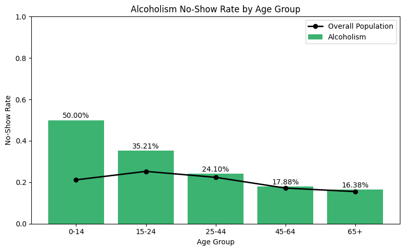

```python
# 9(b).

plot_condition_vs_overall(df_merged, 'alcoholism', 'Alcoholism')
```

> Similar to hypertension and diabetes, alcoholism is relatively uncommon among patients under the age of 25 and becomes more prevalent after age 25. Women with alcoholism appear to have higher no-show rates compared to women without alcoholism. Additionally, across most age groups, women with alcoholism tend to have higher no-show rates than men with alcoholism. Across all age groups, people with alcoholism are more likely to no-show than their peers in the overall population.

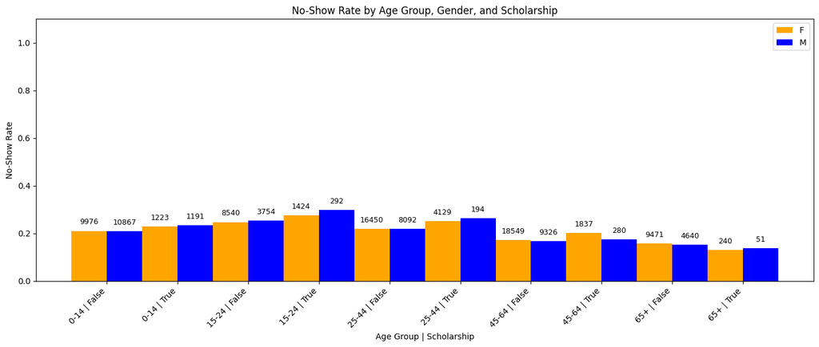

```python
# 10(a).

plot_age_gender_condition(df_merged, 'scholarship', 'Scholarship')
```

**Figure 11:** Bar graph showing no-show rate by age, gender and scholarship.

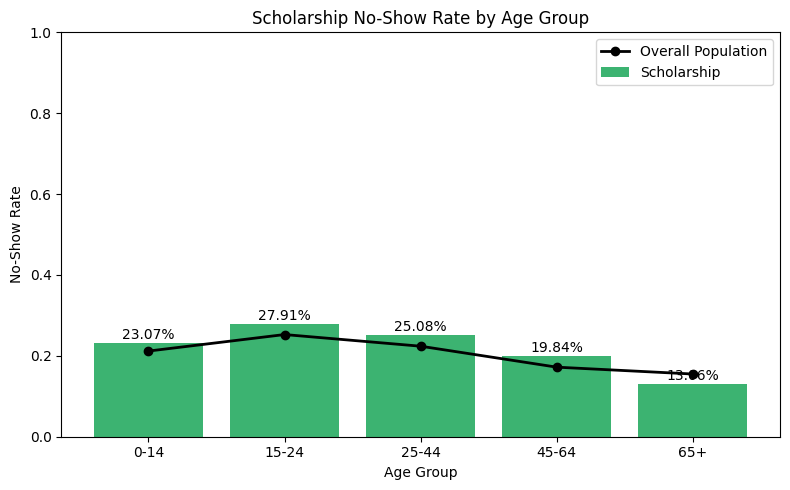

```python
# 10(b).

plot_condition_vs_overall(df_merged, 'scholarship', 'Scholarship')
```

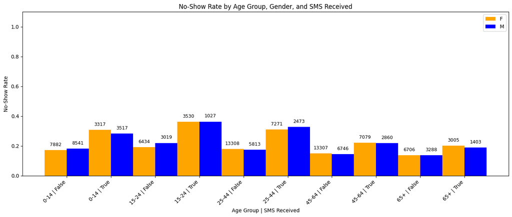

```python
# 11(a).

plot_age_gender_condition(df_merged, 'sms_received', 'SMS Received')
```

**Figure 13:** Bar graph showing no-show rate by age, gender and SMS received.

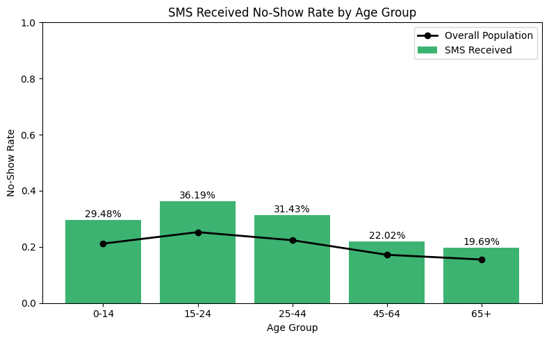

```python
# 11(b).

plot_condition_vs_overall(df_merged, 'sms_received', 'SMS Received')
```

### Repeated no-shows: Among patients with more than one appointment, what proportion no-show multiple appointments? Are people who no-show multiple appointments getting SMS messages? This captures patterns of habitual non-attendance.

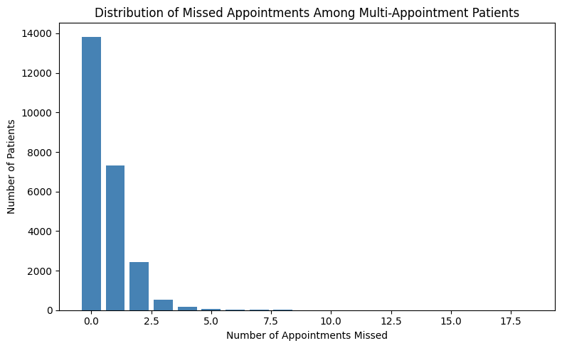

```python
# Compute total booked and total missed appointments per patient
patient_summary = df_merged.groupby('patientid')['no_show'].agg(
    total_booked='count',
    total_missed=lambda x: x.sum()  # True = 1, False = 0
).reset_index()

multi_patients = patient_summary[patient_summary['total_booked'] > 1]

miss_distribution = (
    multi_patients['total_missed']
    .value_counts()
    .sort_index()
)

plt.figure(figsize=(8,5))
plt.bar(miss_distribution.index, miss_distribution.values, color='steelblue')

plt.xlabel('Number of Appointments Missed')
plt.ylabel('Number of Patients')
plt.title('Distribution of Missed Appointments Among Multi-Appointment Patients')

plt.tight_layout()
plt.show()
```

**Figure 15:** Bar graph showing the distribution of missed appointments among multi-appointment patients.

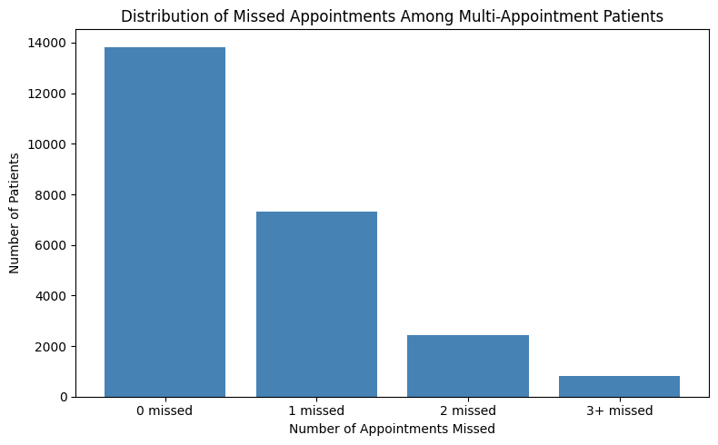

```python
# Make a true copy
multi_patients = multi_patients.copy()

# Assign miss_category
multi_patients['miss_category'] = pd.cut(
    multi_patients['total_missed'],
    bins=[-1, 0, 1, 2, 100],
    labels=['0 missed', '1 missed', '2 missed', '3+ missed']
)

# Count per category
category_dist = multi_patients['miss_category'].value_counts().sort_index()

plt.figure(figsize=(8,5))
plt.bar(category_dist.index, category_dist.values, color='steelblue')

plt.xlabel('Number of Appointments Missed')
plt.ylabel('Number of Patients')
plt.title('Distribution of Missed Appointments Among Multi-Appointment Patients')

plt.tight_layout()
plt.show()
```

**Figure 16:** Bar graph showing the distribution of missed appointments among multi-appointment patients.

```python
# Step 1: Compute total appointments and total missed per patient
patient_summary = (
    df_merged
    .groupby('patientid')
    .agg(total_booked=('appointmentid', 'count'),
         total_missed=('no_show', 'sum'))
    .reset_index()
)

# Assuming patient_summary has total_missed per patient
high_miss_ids = patient_summary[patient_summary['total_missed'] > 1]

# Count the number of unique patients
num_high_miss_patients = high_miss_ids['patientid'].nunique()

print(f"Number of patients who have missed 2+ appointments: {num_high_miss_patients}")
```

```
Number of patients who have missed 2+ appointments: 3226
```

```python
two_plus_missed = 3226
perc_high_miss = (two_plus_missed / num_patients)*100
print(f"{perc_high_miss}% of total patients have missed 2+ appointments")
```

```
5.178253262492174% of total patients have missed 2+ appointments
```

> What we can see is the majority of patients have missed 0 or 1 appointments, with about 5.18% missing 2 or more appointments.

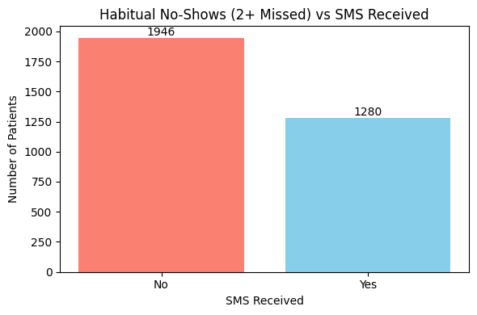

```python
# Compute total booked and total missed per patient
patient_summary = (
    df_merged
    .groupby('patientid')
    .agg(total_booked=('appointmentid', 'count'),
         total_missed=('no_show', 'sum'))  # True=1, False=0
    .reset_index()
)

# Keep only patients with more than 1 appointment
multi_patients = patient_summary[patient_summary['total_booked'] > 1].copy()

# Assign miss_category
multi_patients['miss_category'] = pd.cut(
    multi_patients['total_missed'],
    bins=[-1, 0, 1, 100],
    labels=['0 missed', '1 missed', '2+ missed']
)

# Filter to "2+ missed"
habitual_no_shows = multi_patients[multi_patients['miss_category'] == '2+ missed']

# Get SMS info from df_merged (take first value per patient)
sms_info = df_merged.groupby('patientid')['sms_received'].first().reset_index()

# Merge with habitual_no_shows
habitual_no_shows = habitual_no_shows.merge(sms_info, on='patientid', how='left')

# Count number of patients by SMS received
sms_counts = habitual_no_shows['sms_received'].value_counts()

# Plot
plt.figure(figsize=(6,4))
bars = plt.bar(sms_counts.index, sms_counts.values, color=['salmon','skyblue'])

# Add labels on top of each bar
for bar in bars:
    height = bar.get_height()
    plt.text(bar.get_x() + bar.get_width()/2, height + 1, str(int(height)),
             ha='center', va='bottom', fontsize=10)

plt.xlabel('SMS Received')
plt.ylabel('Number of Patients')
plt.title('Habitual No-Shows (2+ Missed) vs SMS Received')
plt.xticks([0,1], ['No', 'Yes'])
plt.tight_layout()
plt.show()
```

**Figure 17:** Bar graph showing habitual (2+) no-show patients versus whether they received an SMS message.

```python
perc_no_sms = (1946 / num_high_miss_patients)*100

print(f"{perc_no_sms}% of this category did not receive an sms.")
```

```
60.322380657160565% of this category did not receive an sms.
```

> We saw earlier that people who received an SMS message had a higher rate of no-shows than people who did not. Here we see that, 60.32% of the patients who have missed multiple appointments (2+) did not receive an SMS message.

### What patient characteristics are associated with higher no-show rates?

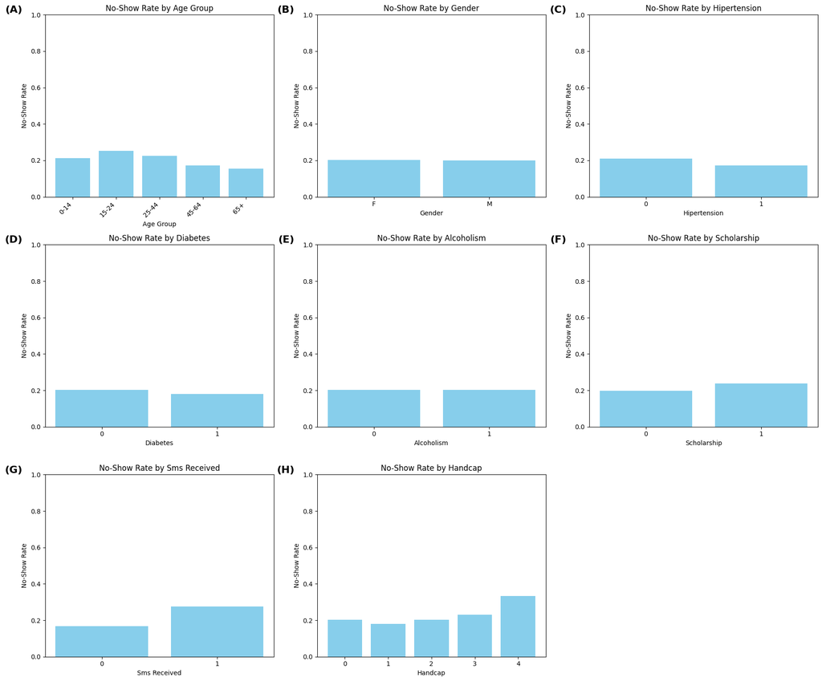

```python
vars_to_plot = ['age_group', 'gender', 'hipertension', 'diabetes',
                'alcoholism', 'scholarship', 'sms_received', 'handcap']

n_vars = len(vars_to_plot)
n_cols = 3
n_rows = (n_vars + n_cols - 1) // n_cols  # ceil division

fig, axes = plt.subplots(n_rows, n_cols, figsize=(18, 5*n_rows))
axes = axes.flatten()

panel_letters = list(string.ascii_uppercase)  # A, B, C, ...

for i, var in enumerate(vars_to_plot):
    ax = axes[i]

    # Compute no-show rate
    rates = df_merged.groupby(var)['no_show'].mean().sort_index()

    # Bar plot
    ax.bar(rates.index.astype(str), rates.values, color='skyblue')
    ax.set_ylim(0,1)
    ax.set_ylabel('No-Show Rate')
    ax.set_xlabel(var.replace("_"," ").title())
    ax.set_title(f"No-Show Rate by {var.replace('_',' ').title()}")

    # Panel letter annotation in top-left corner
    ax.text(-0.1, 1.05, f"({panel_letters[i]})", transform=ax.transAxes,
            fontsize=16, fontweight='bold', va='top', ha='right')

    # Fix for age_group x-tick rotation
    if var == 'age_group':
        ax.set_xticks(range(len(rates)))
        ax.set_xticklabels(rates.index.astype(str), rotation=45, ha='right')

# Remove empty subplots
for j in range(i+1, len(axes)):
    fig.delaxes(axes[j])

plt.tight_layout()
plt.show()
```

**Figure 18 (A) - (H):** A. Bar graph showing no-show rate by age group. B. Bar graph showing no-show rate by gender. C. Bar graph showing no-show rate by hipertension. D. Bar graph showing no-show rate by diabetes. E. Bar graph showing no-show rate by alcoholism. F. Bar graph showing no-show rate by scholarship. G. Bar graph showing no-show rate by SMS received. H. Bar graph showing no-show rate by Handcap.

## Conclusions

> This analysis explored factors associated with no-show behavior in over 110,000 medical appointments. The primary objective was to investigate how demographic characteristics, medical conditions, program enrollment, and SMS reminders relate to appointment attendance.

> *Key Findings*

> Overall, approximately 20.19% of appointments resulted in a no-show.

> **Age emerged as one of the strongest observable patterns.** Patients between the ages of 15–44 had the highest no-show rates, particularly those aged 15–24. No-show rates declined through middle age and were lowest among patients aged 65+, though rates increased slightly among the very elderly. This suggests life-stage factors may play a role in attendance behavior.

> **Gender showed minimal effect.** No-show rates were nearly identical between males and females across most age groups with no other variables applied. We do start to see differing behavior between the sexes when other variables are applied.

> Scholarship recipients exhibited higher no-show rates, particularly in younger age groups. This may reflect broader socioeconomic challenges, though no direct socioeconomic variables were available in the dataset.

> **SMS reminders were associated with higher no-show rates.** Across all age groups, patients who received an SMS reminder had higher no-show rates than those who did not. However, because this dataset does not indicate how SMS reminders are assigned, this relationship should not be interpreted as evidence that reminders increase no-shows. It is possible that reminders are targeted toward patients already identified as higher risk.

> **Repeated no-show behavior was relatively uncommon.** Only about 5.18% of patients missed two or more appointments. Among these habitual no-show patients, approximately 60% did not receive an SMS reminder.

> Future analysis could examine the time difference between the scheduled date and appointment date. Longer wait times may increase the likelihood of missed appointments, and incorporating this variable could provide additional insight into no-show behavior.

> I recognize that there is 1 appointment with a negative age (-1). This is likely a data entry error. For this exploratory analysis, 1 appointment out of 110K+ appointments will have little affect on this level of analysis. However, if we decided to create a model with this data, we would want to clean this.

> **Limitations**

> Several limitations restrict interpretation:

> The dataset is observational; therefore, relationships identified are correlational, not causal.

> There is no information about socioeconomic status, transportation access, distance to clinic, or employment status.

> The dataset does not clarify how SMS reminders are assigned.

> The “Handcap” variable lacks descriptive context regarding severity or type of disability.

> Geographic analysis is limited to neighborhood labels without spatial coordinates.

> Because of these limitations, findings should be interpreted as descriptive patterns rather than predictive or causal conclusions.

```python
# Running this cell will execute a bash command to convert this notebook to an .html file
!python -m nbconvert --to html Investigate_a_Dataset_No_Show_Appointments.ipynb
```

```
[NbConvertApp] Converting notebook Investigate_a_Dataset_No_Show_Appointments.ipynb to html
[NbConvertApp] WARNING | Alternative text is missing on 18 image(s).
[NbConvertApp] Writing 1585196 bytes to Investigate_a_Dataset_No_Show_Appointments.html
```